# Module 7. Generalized estimating equations

Slides

# Why marginal models?

## GEE answers a question about populations, not individuals

- **Population-average (marginal)**: how does the *average* outcome in the population change? $\mu_{ij} = E(Y_{ij} \mid \mathbf{x}_{ij})$
- **Subject-specific (conditional)**: how does the outcome change *for a given participant*? $E(Y_{ij} \mid \mathbf{x}_{ij}, \mathbf{b}_i)$
- Identity link: the two coincide. Logit link: they do not (Module 8).
- In GEE a participant is a **cluster**; clusters are independent.

## GEE keeps the GLM score equations and adds two ideas

1. Weight each participant’s residuals jointly, using a **working correlation** (a guess).
2. Do **not** trust the guess for the standard errors: use the **sandwich**.

> The mean model must be right. The correlation model only has to be reasonable.

## The generalized estimating equations

$$U(\boldsymbol\beta) = \sum_{i=1}^{N} D_i^\top V_i^{-1} (\mathbf{y}_i - \boldsymbol\mu_i) = \mathbf{0},
\qquad V_i = \phi\, A_i^{1/2} R_i(\boldsymbol\alpha) A_i^{1/2}$$

- $g(\mu_{ij}) = \mathbf{x}_{ij}^\top\boldsymbol\beta$: marginal mean model; $D_i = \partial\boldsymbol\mu_i / \partial\boldsymbol\beta^\top$
- $A_i$: variance functions $v(\mu_{ij})$; $\phi$: scale; $R_i(\boldsymbol\alpha)$: working correlation
- $R_i = I$: ordinary GLM score equations; identity link: generalized least squares

## Why a wrong working correlation does not bias $\hat{\boldsymbol\beta}$

- At the true $\boldsymbol\beta$: $E(\mathbf{y}_i - \boldsymbol\mu_i) = \mathbf{0}$ if the mean model is right.
- So $E\{U(\boldsymbol\beta)\} = \mathbf{0}$ **whatever** matrix $V_i^{-1}$ multiplies the residuals.
- Unbiased estimating equations give **consistent** estimates ($N \to \infty$).
- The working correlation changes only the weights, hence **efficiency**.

## The sandwich: bread from the model, meat from the data

$$\widehat{\operatorname{Var}}(\hat{\boldsymbol\beta}) = B^{-1} M B^{-1},\quad
B = \sum_i D_i^\top V_i^{-1} D_i,\quad
M = \sum_i D_i^\top V_i^{-1} \hat{\mathbf{e}}_i\hat{\mathbf{e}}_i^\top V_i^{-1} D_i$$

- If $V_i$ is right, $M \approx B$ and the sandwich reduces to the **model-based** $B^{-1}$.
- If $V_i$ is wrong, $B^{-1}$ is wrong; $B^{-1}MB^{-1}$ is still consistent.
- `geeglm()` reports the sandwich; the model-based variance is in `fit$geese$vbeta.naiv`.

# GEE for a continuous outcome: WALK

## Fitting GEE with geepack: sort, factor id, waves

```r
walk <- load_walk() |> arrange(id, month)      # clusters contiguous, in time order
gee_walk <- geeglm(sbp ~ visit_f * arm, id = factor(id), waves = visit,
                   data = walk, corstr = "exchangeable")
emm_walk <- emmeans(gee_walk, ~ visit_f | arm)  # uses the sandwich covariance
contrast(contrast(emm_walk, list(change_m12 = c(-1, 0, 0, 0, 0, 1))),
         "trt.vs.ctrl", by = NULL)
```

- `id = factor(id)`: a character id (“W001”) gives “NAs introduced by coercion” and **wrong clusters**.
- Rows of a cluster must be contiguous; `waves` tells AR(1)/unstructured which visit each row is.

## GEE and the mixed model agree for a continuous outcome

Difference in mean change in SBP, baseline to month 12 (mmHg, 95% CI)

| Contrast | GEE (exchangeable) | Primary LMM | Truth |
| --- | --- | --- | --- |
| SP vs UC | -5.40 (-8.09 to -2.71) | -5.38 (-8.17 to -2.58) | -4.6 |
| EP vs UC | -8.98 (-11.71 to -6.25) | -8.97 (-11.79 to -6.15) | -8.1 |

- Working correlation $\hat\alpha$ = 0.76; 360 clusters.
- Identity link: GEE and LMM target the same quantity. They differ in the missing-data assumption (MCAR vs MAR).

## Try it

Workbook **Exercise 1**: fit the WALK GEE, find the scale and working correlation, and estimate the difference in mean change at month 12.

# Working correlation structures

## Four common working correlations

| `corstr` | Correlation between occasions $j$ and $k$ | Parameters |
| --- | --- | --- |
| `independence` | 0 | 0 |
| `exchangeable` | $\alpha$ | 1 |
| `ar1` | $\alpha^{\lvert j-k\rvert}$ | 1 |
| `unstructured` | $\alpha_{jk}$ | $n(n-1)/2$ |

- Same shapes as Module 5, different role: a weighting scheme, not part of a likelihood.

## Estimates barely move; model-based SEs move a lot

| Working correlation | Arm vs UC | Estimate | Robust SE | Model-based SE |
| --- | --- | --- | --- | --- |
| independence | SP | -5.80 | 1.59 | 2.53 |
| independence | EP | -9.11 | 1.65 | 2.56 |
| exchangeable | SP | -5.40 | 1.37 | 1.26 |
| exchangeable | EP | -8.98 | 1.39 | 1.28 |
| ar1 | SP | -5.41 | 1.39 | 1.63 |
| ar1 | EP | -9.20 | 1.40 | 1.65 |
| unstructured | SP | -5.51 | 1.37 | 1.45 |
| unstructured | EP | -9.07 | 1.39 | 1.47 |

## The working correlation changes precision, not the target

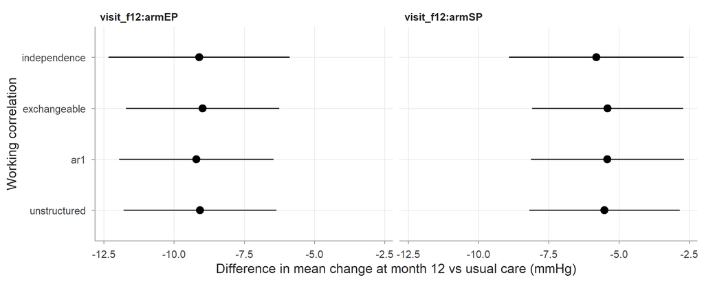

## Choosing the working correlation in practice

- Follow the **design**: few occasions, many clusters: unstructured or exchangeable; many equally spaced: AR(1).
- Look at the **empirical correlation** of Pearson residuals.
- Compare **model-based and sandwich SEs**: close agreement suggests a good guess.
- **Few clusters**: keep it simple. **Prespecify** it.
- `geepack::QIC()` exists, but QIC is weak for choosing correlation structures.

|  | QIC | CIC |
| --- | --- | --- |
| independence | 327580 | 17.97 |
| exchangeable | 328768 | 17.26 |
| ar1 | 328858 | 17.23 |

## Try it

Workbook **Exercise 2**: refit WALK with independence, exchangeable and AR(1) working correlations and compare estimates, robust and model-based SEs.

# Model-based versus robust standard errors

## For CLEAR the two SEs are close

|  | Estimate | Model-based SE | Robust SE | Mancl-DeRouen SE |
| --- | --- | --- | --- | --- |
| (Intercept) | 0.0849 | 0.1635 | 0.1534 | 0.1550 |
| week | -0.0634 | 0.0190 | 0.0189 | 0.0191 |
| armActive | -0.0634 | 0.2308 | 0.2250 | 0.2273 |
| week:armActive | -0.0844 | 0.0292 | 0.0282 | 0.0285 |

- The hand-coded sandwich reproduces `geeglm` to rounding error.
- CLEAR was generated with a random intercept only, so exchangeable is a good guess.

# GEE for binary and count outcomes

## CLEAR: a population-average logistic model

$$\operatorname{logit}\mu_{ij} = \beta_0 + \beta_1 t_{ij} + \beta_2\text{Active}_i + \beta_3 t_{ij}\text{Active}_i$$

```r
gee_clear <- geeglm(itch ~ week * arm, id = factor(id), waves = visit,
                    data = clear, family = binomial, corstr = "exchangeable")
```

- $\exp(\hat\beta_3)$ = 0.919 (95% CI 0.870 to 0.971): extra weekly multiplicative change in the **population** odds on active treatment.
- Over 12 weeks: odds ratio 0.36.

## Report probabilities and risk differences too

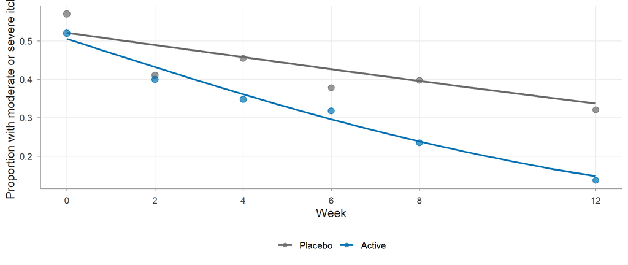

Week 12: 0.34 (placebo) vs 0.15 (active); risk difference -0.19 (95% CI -0.30 to -0.08).

## DIARY: a log-linear marginal model with an offset

```r
gee_diary <- geeglm(migraine_days ~ post * arm + offset(log(days)),
                    id = factor(id), waves = period + 1, data = diary,
                    family = poisson, corstr = "exchangeable")
emmeans(gee_diary, ~ arm | post, offset = log(28), type = "response")
```

- Ratio of rate ratios $\exp(\hat\beta_3)$ = 0.79 (95% CI 0.61 to 1.01); truth 0.67.
- Expected migraine days per 28 days after baseline: 4.7 (placebo), 3.5 (active).
- Scale $\hat\phi$ = 3.5: overdispersion is absorbed by $\phi$ and the sandwich.

## Try it

Workbook **Exercises 3 and 4**: CLEAR binary GEE (odds ratios, predicted probabilities, risk difference) and DIARY count GEE (rate ratio, expected days per 28 days).

# How many clusters?

## The sandwich needs many clusters

- The meat $M$ averages $N$ cluster outer products: noisy and **biased downwards** when $N$ is small.
- **Mancl–DeRouen**: replace $\hat{\mathbf{e}}_i$ by $(I - H_{ii})^{-1}\hat{\mathbf{e}}_i$, with $H_{ii} = D_i B^{-1} D_i^\top V_i^{-1}$ (Mancl and DeRouen 2001).
- Easy to code by hand; for a linear model it equals the leave-one-cluster-out jackknife.

## Simulation: 10, 40 and 200 clusters

| N | Empirical SD | Mean sandwich SE | Mean MD SE | Cover model | Cover sandwich | Cover MD (z) | Cover MD (t) |
| --- | --- | --- | --- | --- | --- | --- | --- |
| 10 | 0.422 | 0.382 | 0.478 | 0.877 | 0.915 | 0.964 | 0.988 |
| 40 | 0.219 | 0.212 | 0.223 | 0.858 | 0.930 | 0.940 | 0.955 |
| 200 | 0.099 | 0.097 | 0.098 | 0.856 | 0.942 | 0.947 | 0.948 |

Monte Carlo SE of each coverage: about 0.007 (1,000 replications).

## Coverage improves with clusters, not with observations

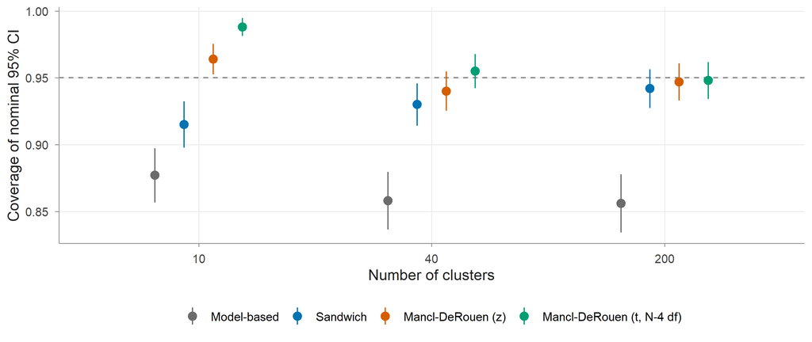

## Try it

Workbook **Exercise 5**: run a smaller version of the simulation and compute Monte Carlo standard errors.

# Missing data and weighted GEE ADVANCED

## Standard GEE needs MCAR

- GEE requires $E(Y_{ij} - \mu_{ij} \mid \text{observed}) = 0$.
- In CLEAR, dropout depends on the **last observed severity** (MAR).
- Those still present at week 12 have less itch than the whole population: unweighted GEE is biased.
- Likelihood methods are protected under MAR; GEE is not.

## Inverse-probability weights let observed participants stand in for dropouts

$$\hat\pi_{ij} = \prod_{k=2}^{j} \widehat{P}(R_{ik} = 1 \mid R_{i,k-1} = 1, \text{last severity}, \text{arm}),
\qquad w_{ij} = 1 / \hat\pi_{ij}$$

```r
drop_model <- glm(stay ~ prev_sev + arm, family = binomial, data = risk)
gee_ipw <- geeglm(itch ~ week * arm, id = factor(id), data = clear_w,
                  family = binomial, corstr = "independence", weights = ipw)
```

- Use an **independence** working correlation with observation-level weights (Robins et al. 1995).

## IPW moves the placebo slope towards the truth

|  | True marginal | Unweighted | SE unw. | IPW | SE IPW |
| --- | --- | --- | --- | --- | --- |
| (Intercept) | 0.1158 | 0.0673 | 0.1539 | 0.0495 | 0.1538 |
| week | -0.0361 | -0.0724 | 0.0196 | -0.0570 | 0.0199 |
| armActive | 0.0076 | -0.0522 | 0.2260 | -0.0345 | 0.2272 |
| week:armActive | -0.0996 | -0.0781 | 0.0291 | -0.0791 | 0.0300 |

- Weights 1.00 to 1.85. Differences are below one SE: one dataset cannot prove the bias.
- A 20,000-participant simulation (notes, script `07b`) shows the bias in the placebo slope and its removal by IPW.
- SEs treat the estimated weights as known: **approximate**.

## Try it

Workbook **Exercise 6** (advanced): build the dropout model and weights for CLEAR and compare weighted with unweighted GEE.

# Summary

## Key messages

- GEE estimates **population-average** effects from a marginal mean model.
- The **working correlation** affects efficiency, not consistency.
- Report **sandwich SEs**, and correct them (Mancl–DeRouen, $t$) when clusters are few.
- Use `id = factor(id)` and sorted data with `geeglm`.
- Standard GEE needs **MCAR**; under MAR dropout use a likelihood method or **IPW-GEE**.

Mancl, Lloyd A., and Timothy A. DeRouen. 2001. ‘A Covariance Estimator for GEE with Improved Small-Sample Properties’. *Biometrics* 57 (1): 126–34. https://doi.org/10.1111/j.0006-341X.2001.00126.x.

Robins, James M., Andrea Rotnitzky, and Lue Ping Zhao. 1995. ‘Analysis of Semiparametric Regression Models for Repeated Outcomes in the Presence of Missing Data’. *Journal of the American Statistical Association* 90 (429): 106–21. https://doi.org/10.1080/01621459.1995.10476493.